# Data Wrangling Project Part 2

## Correlation Between Price and Overall experience

Let’s check whether listing with higher price will give higher overall experience as well using simple scatterplot. We will scale the listing price to log10 units. We only collect listing with non-NULL value for the review scores rating. We will also filter the data by collecting listing that has more than 10 number of reviews.

```r
out_db<-dbGetQuery(con1, "SELECT price, review_scores_rating
                   FROM listing
                   WHERE review_scores_rating IS NOT NULL AND number_of_reviews > 10"
                   )
head(out_db)
```

```
  price review_scores_rating
1  1694                   97
2  1095                   96
3   541                   98
4   796                   95
5  2175                   96
6  4400                  100
```

Let’s visualize it!

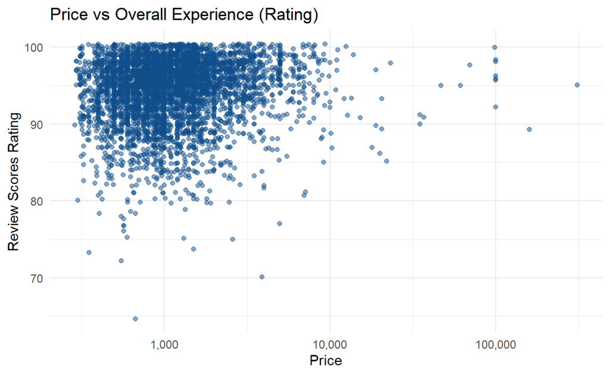

```r
set.seed(123)
out_db %>%
  ggplot(aes(x = price,
             y = review_scores_rating)) +
  geom_jitter(color = "dodgerblue4", alpha = 0.5) +
  scale_x_log10(label = number_format(big.mark = ",")) +
  labs(x = "Price",
       y = "Review Scores Rating",
       title = "Price vs Overall Experience (Rating)")
```

Most of the listing room has price higher than 300 bhat (2.5 in log10 scale), but there is one room that has price lower than 300 bhat and has high review scores rating. Based on the distribution, no listing room has overall experience lower than 80 for listing room with price higher than 10,000 bhat (4 in log10 scale). For price ranging from 300 bhat to 10,000 bhat, there is no correlation between price and overall experience. However, as the price goes up, people tend to be give higher rating. ## Amenities

Let’s continue by checking the most common amenities that is included for the given service.

```r
out_db <- dbGetQuery(con1,
                   "SELECT amenities,
                   review_scores_rating,
                   price
                   FROM listing"
                   )
head(out_db)
```

```
                                                                                                                                                                                                                                                                                                            …
1 Microwave, Pool, Smoke alarm, Dryer, Long term stays allowed, Hair dryer, Stove, Iron, Free parking on premises, Essentials, Dishes and silverware, Washer, Hot water, Patio or balcony, Hangers, Air conditioning, Luggage dropoff allowed, Kitchen, Gym, Fire extinguisher, Elevator, TV, Dedicated work…
2                                                                                                                                                                                                                                                         Cable TV, Kitchen, Air conditioning, Free parking …
3                                                                                                                                                             Cable TV, TV, Pool, Shampoo, Hot tub, Heating, First aid kit, Gym, Wifi, Long term stays allowed, Smoke alarm, Fire extinguisher, Kitchen, Ele…
4                                      Dedicated workspace, Air conditioning, Hair dryer, Microwave, Essentials, Free parking on premises, Cable TV, Carbon monoxide alarm, Dishes and silverware, Long term stays allowed, Iron, TV, Elevator, Wifi, Shampoo, Pool, Kitchen, Refrigerator, Hangers, Smoke a…
5                                                                                                                                                                                                                                                                                                           …
6                                                                                                                                                                                                                                                                    Cable TV, Kitchen, Air conditioning, Fr…
  review_scores_rating price
1                   97  1694
2                   NA   924
3                   NA  1188
4                   96  1095
5                   NA   800
6                   NA  4619
```

The amenities is still in a long string format. To process this data, we will split the string into individual amenities indicated by the comma. To prevent the possibility of mistyping or other free text error, we will convert all alphabets into lowercase.

```r
out_db <- out_db %>%
  mutate(amenities = tolower(amenities))
out_db %>%
  head()
```

```
                                                                                                                                                                                                                                                                                                            …
1 microwave, pool, smoke alarm, dryer, long term stays allowed, hair dryer, stove, iron, free parking on premises, essentials, dishes and silverware, washer, hot water, patio or balcony, hangers, air conditioning, luggage dropoff allowed, kitchen, gym, fire extinguisher, elevator, tv, dedicated work…
2                                                                                                                                                                                                                                                         cable tv, kitchen, air conditioning, free parking …
3                                                                                                                                                             cable tv, tv, pool, shampoo, hot tub, heating, first aid kit, gym, wifi, long term stays allowed, smoke alarm, fire extinguisher, kitchen, ele…
4                                      dedicated workspace, air conditioning, hair dryer, microwave, essentials, free parking on premises, cable tv, carbon monoxide alarm, dishes and silverware, long term stays allowed, iron, tv, elevator, wifi, shampoo, pool, kitchen, refrigerator, hangers, smoke a…
5                                                                                                                                                                                                                                                                                                           …
6                                                                                                                                                                                                                                                                    cable tv, kitchen, air conditioning, fr…
  review_scores_rating price
1                   97  1694
2                   NA   924
3                   NA  1188
4                   96  1095
5                   NA   800
6                   NA  4619
```

Let’s start collecting all amenities.

```r
list_amenities <- map(out_db$amenities, function(x) x %>%
                        strsplit(", ") %>% unlist() ) %>%
  unlist()
df_amenities <- data.frame(amenities = list_amenities)
head(df_amenities)
```

```
                amenities
1               microwave
2                    pool
3             smoke alarm
4                   dryer
5 long term stays allowed
6              hair dryer
```

After all amenities are collected, it’s time to create a dataframe that consists of the amenities and it’s respective frequency. We will normalize the frequency into percentage to reflect of all listing available, what percentage of listing use the mentioned amenities.

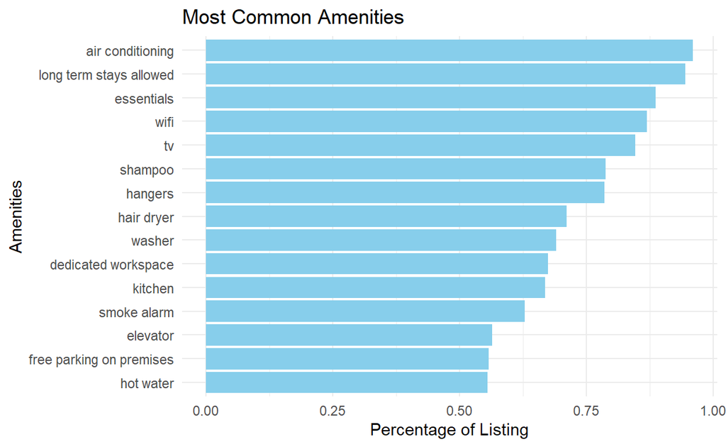

```r
# Prepare top 15 amenities by ratio
df_viz <- df_amenities %>%
  count(amenities, name = "frequency") %>%
  mutate(n_data = nrow(out_db),
         ratio = frequency/nrow(out_db)) %>%
  arrange(desc(ratio)) %>%
  head(15)
# Visualization
df_viz %>%
  ggplot(aes(x = ratio,
             y = amenities %>% reorder(ratio))
         ) +
  geom_col(fill = "skyblue") +
  labs(x = "Percentage of Listing",
       y = "Amenities",
       title = "Most Common Amenities")
```

Almost all of the available listing has `Air conditioning` and `Long term stays allowed`, followed by `Essentials`, `Wifi`, and `TV`. More than 60% of all listing also has `Dedicated workspace` and `Kitchen`, which may require more spaces outside the bedroom. According to [Airbnb](https://www.airbnb.com/help/article/2343/what-are-essential-amenities), essentials amenities including:

- Toilet paper
- Soap (for hands and body)
- One towel per guest
- One pillow per guest
- Linens for each guest bed

Essential amenities are the basic items that a guest expects in order to have a comfortable stay. So we can check the distribution of the overall experience from listing with and without `Essentials` amenities.

```r
df_viz <- out_db %>%
  filter(!is.na(review_scores_rating)) %>%
  mutate(has_essential = str_detect(amenities, "essentials"))  %>%
  filter(has_essential == "TRUE"|has_essential == "FALSE")
```

We will visualize the data using boxplot for each category.

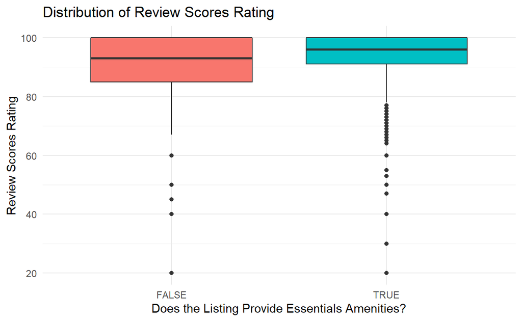

```r
df_viz %>%
  ggplot(aes(x = has_essential,
             y = review_scores_rating,
             fill = has_essential,
             na.rm = TRUE)) +
  geom_boxplot() +
  labs(x = "Does the Listing Provide Essentials Amenities?",
       y = "Review Scores Rating",
       title = "Distribution of Review Scores Rating") +
  theme(legend.position = "none")
```

Listing room that has `Essentials` included in the amenities tend to have slightly higher review scores rating based on the median (the middle line from the box) compared to listing that does not include `Essentials`.

## Listing Map

Since visualizing a large number of marker/listing to the map will take a long time, in this part I restrict to only show the first 5,000 listings.

```r
out_db<- dbGetQuery(con1,
                   "SELECT id, name,
                   listing_url,
                   latitude,
                   longitude,
                   price,
                   review_scores_rating,
                   number_of_reviews,
                   neighbourhood_cleansed,
                   listing.host_id,
                   host_info.host_name
                   FROM listing
                   LEFT JOIN host_info
                   ON listing.host_id = host_info.host_id
                   LIMIT 5000"
                   )
head(out_db)
```

```
     id                                               name
1 27942                   Town House (1) bedroom available
2 28354 Place near Metro and Shopping Mall ( Monthly only)
3 28745                  modern-style apartment in Bangkok
4 35656                                     Nice townhouse
5 35780     Spacious one bedroom at The Kris Condo Bldg. 3
6 35807                                   The escape Condo
                         listing_url latitude longitude price
1 https://www.airbnb.com/rooms/27942 13.73463  100.4754   924
2 https://www.airbnb.com/rooms/28354 13.81152  100.5662  1095
3 https://www.airbnb.com/rooms/28745 13.75232  100.6240   800
4 https://www.airbnb.com/rooms/35656 13.82622  100.6694  4619
5 https://www.airbnb.com/rooms/35780 13.78827  100.5706   800
6 https://www.airbnb.com/rooms/35807 13.67307  100.6077  1720
  review_scores_rating number_of_reviews neighbourhood_cleansed
1                   NA                 0            Bangkok Yai
2                   96                52             Chatu Chak
3                   NA                 0              Bang Kapi
4                   NA                 0            Khan Na Yao
5                   80                 1              Din Daeng
6                   NA                 0                Bang Na
  host_id    host_name
1  120462     "Donald"
2  121848    "Jaruwan"
3  123784 "Familyroom"
4  153315   "Jeeranut"
5  153730    "Sirilak"
6  153749   "Waraporn"
```

Some listing may not have a host name or even the name for the listing, therefore we will modify the value. We will fill missing value from the host name and name column with the string *No Host Name* and *No Name*.

```r
df_viz <- out_db %>%
  replace_na(list(name = "No Name", host_name = "No Host Name"))
```

Now we will draw the map. We will also create a custom popup where we can put several information for each listing.

```r
popup <- paste0("<b>", df_viz$name, "</b><br>",
                "Listing ID: ", df_viz$id, "<br>",
                "Host Name: ", df_viz$host_name, "<br>",
                "Price: ", df_viz$price, "<br>",
                "Review Scores Rating: ",
                ifelse(is.na(df_viz$review_scores_rating),
                       "No Review Yet", df_viz$review_scores_rating) , "<br>",
                "Number of Reviews: ", df_viz$number_of_reviews, "<br>",
                "<a href=", df_viz$listing_url, "> Click for more info</a>"
                )
leaflet(data = df_viz) %>%
  addTiles() %>%
  addMarkers(lng = ~longitude,
             lat = ~latitude,
             popup = popup,
             clusterOptions = markerClusterOptions())
```

[interactive chart not shown]

# Host

We will continue answering the research question by looking at the host data.

## Top Host by Earning

We will see who is the top host based on the total earning cumulated from his/her listings. We will use the following formula to calculate the total earning:

$$Total\ earning = \Sigma_{i=1}^n price_i\times number\ of\ reviews_i \times minimum\ nights_i$$

Notes:

- n: Number of listing for the host
- price: Price of ith listing from the host
- number of reviews: Number of reviews of ith listing
- minimum nights: Minimum night of stay of ith listing

Unfortunately, we don’t have the detailed data on the number of stay for each customer, so we will use the minimum nights as the number of stay so what we actually calculate is the minimum total earning. We use the number of reviews as the proxy of number of customers.

```r
out_db<- dbGetQuery(con1,
                   "SELECT host_id,
                   host_name,
                   SUM(total_earning) as total_earning,
                   COUNT(*) as number_of_listing,
                   AVG(price) as average_price
                   FROM
                      (SELECT listing.host_id,
                      host_info.host_name, price,
                      number_of_reviews,
                      minimum_nights,
                      price * number_of_reviews * minimum_nights as total_earning
                      FROM listing
                      LEFT JOIN host_info
                      ON listing.host_id = host_info.host_id
                      WHERE host_name IS NOT NULL
                      ) as new_table
                  GROUP BY host_id, host_name
                  ORDER BY SUM(total_earning) DESC"
                  )
out_db %>%
  head()
```

```
    host_id                          host_name total_earning
1   2129668                         "Wimonpak"     195524436
2  35082871                               "Ed"     170596856
3   4039620                            "Nadda"      68861699
4  32398198                        "Touchapon"      58527600
5   3785867                            "Julia"      43732045
6 109067398 "มาลี"      41288000
  number_of_listing average_price
1                39      906.9487
2                25     4499.7200
3                 2   187214.0000
4                 2      760.0000
5                 2     3463.5000
6                 2     1100.0000
```

Now we will visualize the top host based on the number of listing for the start, see if some hosts has higher number of listing than others.

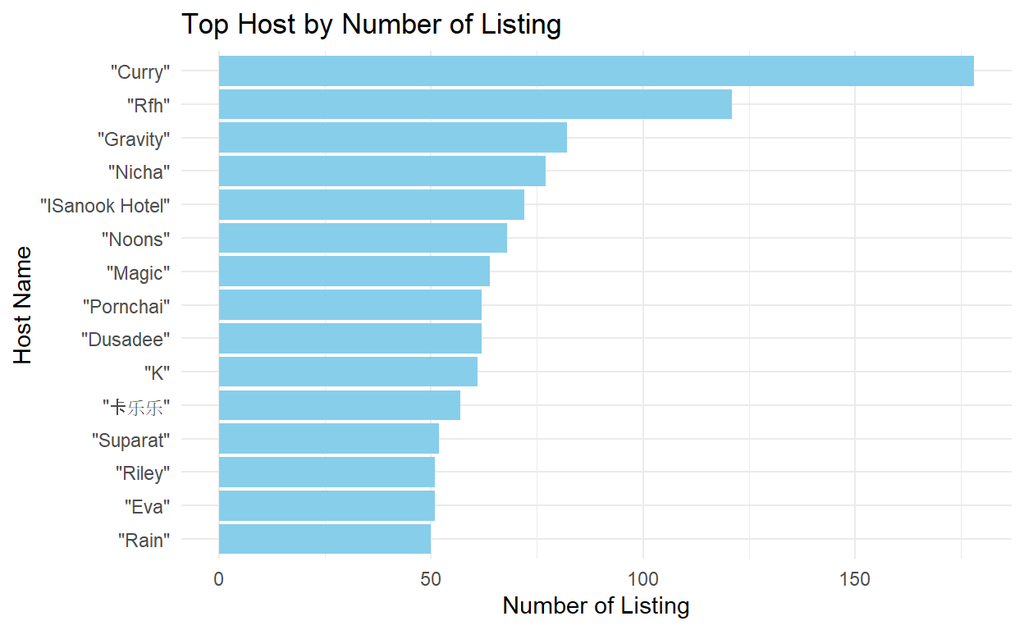

```r
# Get top 15 host by number of listing
df_viz <- out_db %>%
  arrange(desc(number_of_listing)) %>%
  head(15)
df_viz %>%
  ggplot(aes(x = number_of_listing,
             y = host_name %>% reorder(number_of_listing))
         ) +
  geom_col(fill = "skyblue") +
  labs(x = "Number of Listing",
       y = "Host Name",
       title = "Top Host by Number of Listing")
```

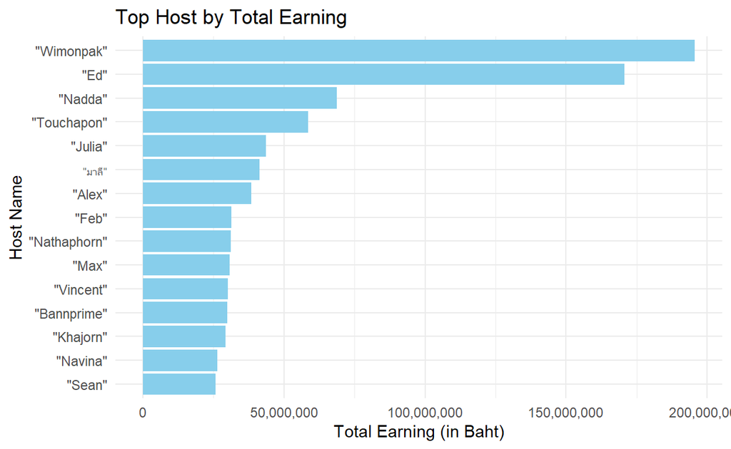

```r
# Get top 15 host by total earning
df_viz <- out_db %>%
  arrange(desc(total_earning)) %>%
  head(15)
df_viz %>%
  ggplot(aes(x = total_earning,
             y = host_name %>% reorder(total_earning))
         ) +
  geom_col(fill = "skyblue") +
  labs(x = "Total Earning (in Baht)",
       y = "Host Name",
       title = "Top Host by Total Earning") +
  scale_x_continuous(labels = number_format(big.mark = ","))
```

So, the list of host name is different from the top host by the number of listing and the top host by total earning. This indicates that a higher number of listings doesn’t guarantee to give more earnings.

Does higher average price of listing from a single host correlate with higher total earning? Let’s answer this questions using scatterplot.

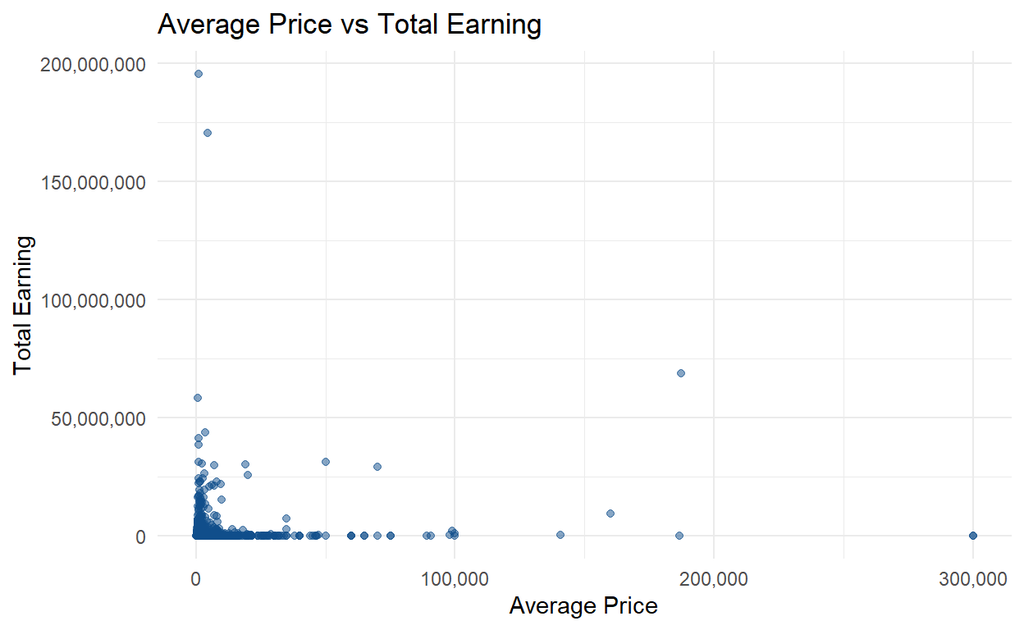

```r
set.seed(123)
out_db %>%
  ggplot(aes(x = average_price,
             y = total_earning)) +
  geom_jitter(color = "dodgerblue4", alpha = 0.5) +
  scale_x_continuous(labels = number_format(big.mark = ",")) +
  scale_y_continuous(labels = number_format(big.mark = ",")) +
  labs(x = "Average Price",
       y = "Total Earning",
       title = "Average Price vs Total Earning")
```

As we can see, there is no visible pattern between average price and total earning. However, some of the most highest total earnings are generated by host with relatively low average price from his/her listings. Therefore, higher average price from a host doesn’t guarantee to give him/her a higher total earning

## Superhost

According to [Airbnb](https://www.airbnb.com/help/article/828/what-is-a-superhost), superhosts are experienced hosts who provide a shining example for other hosts, and extraordinary experiences for their guests.

In here we are interested to check if there is any difference in the distribution of review scores for listing owned by a superhost and normal host.

```r
out_db<-dbGetQuery(con1,
                   "SELECT review_scores_rating,
                   listing.host_id,
                   host_info.host_name,
                   host_info.host_is_superhost
                   FROM listing
                   LEFT JOIN host_info
                   ON listing.host_id = host_info.host_id
                   WHERE review_scores_rating IS NOT NULL AND host_is_superhost IS NOT NULL"
                   )

# Transform is_superhost into logical
out_db <- out_db %>%
  mutate(host_is_superhost = as.logical(host_is_superhost))
out_db %>%
  head()
```

```
  review_scores_rating host_id  host_name host_is_superhost
1                   96  121848  "Jaruwan"             FALSE
2                   80  153730  "Sirilak"             FALSE
3                   98  153793   "Pemika"              TRUE
4                  100  222005 "Athitaya"             FALSE
5                   95  263049      "Tor"             FALSE
6                   96  263049      "Tor"             FALSE
```

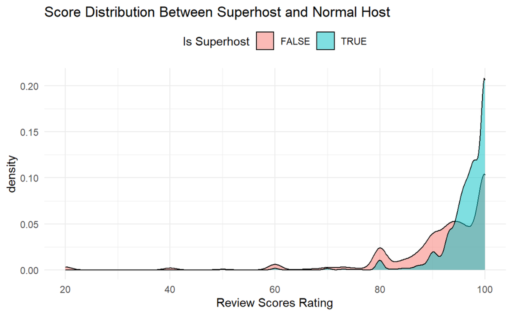

```r
out_db %>%
  ggplot(aes(x = review_scores_rating,
             fill = host_is_superhost)) +
  geom_density(alpha = 0.5) +
  labs(x = "Review Scores Rating",
       fill = "Is Superhost",
       title = "Score Distribution Between Superhost and Normal Host") +
  theme(legend.position = "top")
```

Both superhost and normal host has the same peak for the distribution, indicating that on average there is no significant difference on review scores rating or the overall experience. However, superhosts has thinner distribution, indicating that superhost tend to have higher review score due to low variability.

Now we will look at the response rate and the acceptance rate between normal host and the superhost. The following is the detail description about response rate and acceptance rate according to [Airbnb](https://www.airbnb.com/resources/hosting-homes/a/understanding-response-rate-and-acceptance-rate-86):

- Your response rate measures how consistently you respond within 24 hours to guest inquiries and booking requests.
- Your acceptance rate measures how often you accept or decline reservations. Guest inquiries are not included in the calculation of your acceptance rate.

```r
out_db<-dbGetQuery(con1,
                   "SELECT host_id,
                   host_name,
                   host_response_rate,
                   host_acceptance_rate,
                   host_is_superhost
                   FROM host_info
                   WHERE host_response_rate IS NOT NULL and
                   host_acceptance_rate IS NOT NULL"

                   )

head(out_db)
```

```
  host_id host_name host_response_rate host_acceptance_rate
1  153793  "Pemika"             "100%"               "100%"
2  263049     "Tor"              "75%"               "100%"
3  292635 "Sukanya"             "100%"               "100%"
4  323158     "Sue"             "100%"               "100%"
5  545890   "Henry"             "100%"               "100%"
6   58920    "Gael"             "100%"               "100%"
  host_is_superhost
1              TRUE
2             FALSE
3              TRUE
4             FALSE
5             FALSE
6             FALSE
```

We need to transform the response rate and acceptance rate to be a proper numeric values by removing the percentage character.

```r
out_db <- out_db %>%
  mutate(host_is_superhost = as.logical(host_is_superhost), # Transform is_superhost into logical

         # Transform acceptance rate and response rate
         host_response_rate = host_response_rate %>%
           str_remove("[%]") %>% str_remove_all('"') %>% as.numeric(),
         host_acceptance_rate = host_acceptance_rate %>%
           str_remove("[%]") %>% str_remove_all('"') %>% as.numeric()
         )
head(out_db)
```

```
  host_id host_name host_response_rate host_acceptance_rate
1  153793  "Pemika"                100                  100
2  263049     "Tor"                 75                  100
3  292635 "Sukanya"                100                  100
4  323158     "Sue"                100                  100
5  545890   "Henry"                100                  100
6   58920    "Gael"                100                  100
  host_is_superhost
1              TRUE
2             FALSE
3              TRUE
4             FALSE
5             FALSE
6             FALSE
```

Let’s see the distribution of the response rate and acceptance rate.

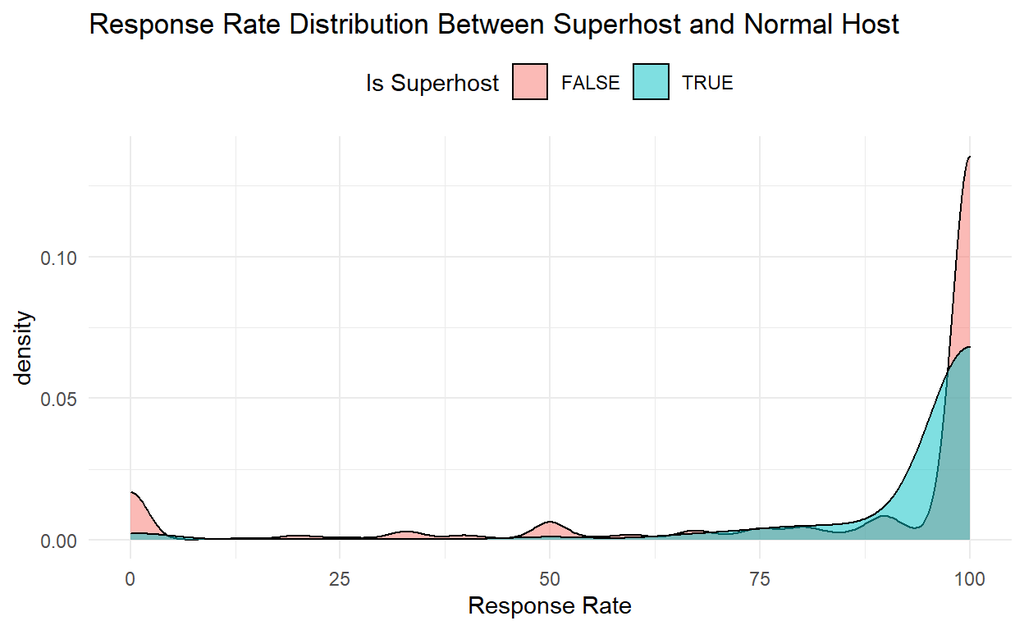

```r
out_db %>%
  ggplot(aes(x = host_response_rate,
             fill = host_is_superhost)) +
  geom_density(alpha = 0.5) +
  labs(x = "Response Rate",
       fill = "Is Superhost",
       title = "Response Rate Distribution Between Superhost and Normal Host") +
  theme(legend.position = "top")
```

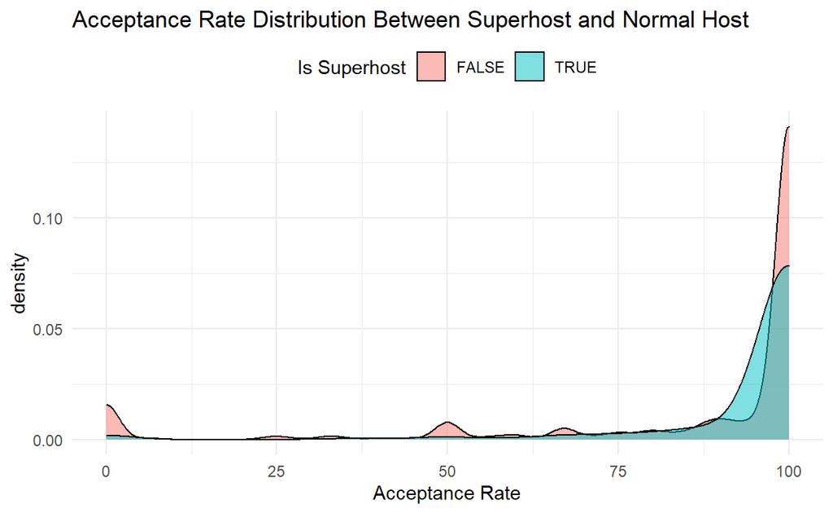

```r
out_db %>%
  ggplot(aes(x = host_acceptance_rate,
             fill = host_is_superhost)) +
  geom_density(alpha = 0.5) +
  labs(x = "Acceptance Rate",
       fill = "Is Superhost",
       title = "Acceptance Rate Distribution Between Superhost and Normal Host") +
  theme(legend.position = "top")
```

## Host Verification

When you host on Airbnb, you may be asked to provide information such as your legal name, date of birth, or government ID so it can then be verified. This is a mandatory step for a host to prevent fraud and other financial crimes. Let’s deep dive into what kind of informations are mostly filled and verified from a host.

```r
out_db<-dbGetQuery(con1,
                   "SELECT host_id, host_name, host_verifications, host_identity_verified
                   FROM host_info
                   WHERE host_identity_verified IS NOT NULL"
                   )

# Transform is_superhost into logical
out_db <- out_db %>%
  mutate(host_identity_verified = as.logical(host_identity_verified))

head(out_db)
```

```
  host_id    host_name
1  120437     "Nuttee"
2  120462     "Donald"
3  120541        "Emy"
4  121848    "Jaruwan"
5  123784 "Familyroom"
6  153315   "Jeeranut"
                                                                             host_verifications
1 "email, phone, reviews, jumio, offline_government_id, selfie, government_id, identity_manual"
2                                                                                "email, phone"
3                                                                                "email, phone"
4              "email, phone, facebook, reviews, jumio, selfie, government_id, identity_manual"
5                                                                                "email, phone"
6                "email, phone, facebook, reviews, jumio, offline_government_id, government_id"
  host_identity_verified
1                   TRUE
2                  FALSE
3                  FALSE
4                   TRUE
5                  FALSE
6                   TRUE
```

Let’s check if there is any host that is not verified yet.

```r
count(filter(out_db, host_identity_verified == F))
```

```
     n
1 3946
```

There are a lot of host that is yet to be verified. Let’s also check if there is any host that has missing value or no host_verification.

```r
out_db %>%
  filter(is.na(host_verifications))
```

```
[1] host_id                host_name
[3] host_verifications     host_identity_verified
<0 rows> (or 0-length row.names)
```

Let’s check the most commonly verified identity.

```r
out_db <- out_db %>%
  mutate(host_verifications = tolower(host_verifications))

list_verification <- map(out_db$host_verifications, function(x) x %>%
                           strsplit(", ") %>% unlist() ) %>%
  unlist() %>% str_remove_all('"')

df_verify <- data.frame(verification = list_verification)
```

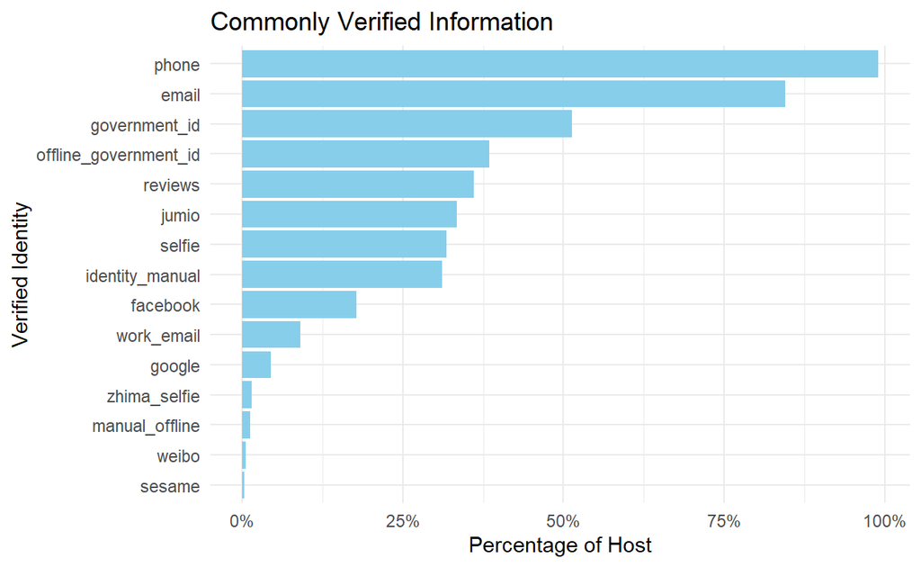

```r
# Prepare top 15 amenities by ratio
df_viz <- df_verify %>%
  count(verification, name = "frequency") %>%
  mutate(n_data = nrow(out_db),
         ratio = frequency/nrow(out_db)) %>%
  arrange(desc(ratio)) %>%
  head(15)
# Visualization
df_viz %>%
  ggplot(aes(x = ratio,
             y = verification %>% reorder(ratio))
         ) +
  geom_col(fill = "skyblue") +
  scale_x_continuous(labels = percent_format()) +
  labs(x = "Percentage of Host",
       y = "Verified Identity",
       title = "Commonly Verified Information")
```

Phone number and email are the most common way to verify a host and has been done by more than 80% of all hosts, followed by the governemnt id of the host.

## Number of Host Joined

Let’s check the number of joined monthly over time, see if there is interesting insights from this data. We will count the number of host joined by monthly period since counting daily frequencies may be too small window of time.

```r
out_db <- dbGetQuery(con1,"SELECT MONTHNAME(host_since) as month,
        YEAR(host_since) as year,
        COUNT(*) as frequency
        FROM host_info
        WHERE host_since IS NOT NULL
        GROUP BY month, year" )

out_db %>%
  head(10)
```

```
       month year frequency
1        May 2010         8
2       June 2010         6
3     August 2010         3
4  September 2010         2
5    October 2010         2
6   November 2010         4
7   December 2010         1
8      April 2011         6
9        May 2011        11
10      June 2011         9
```

Let’s visualize this data using heatmap. To make the graph visually more appealing, we will pad the time period to start from the earliest month (January) of the earliest year and fill the number of host joined with 0 since there is no record of host from this period.

```r
df_viz <- out_db %>%
  mutate(date = paste0(year, "-", month, "-1") %>%
           ymd()
         ) %>%
  pad(interval = "month",
      start_val = ymd( paste0(min(.$year), "-1-1") )
      ) %>%
  mutate(month = month(date, label = T, abbr = F),
         year = year(date)
         ) %>%
  replace_na(list(frequency = 0))
df_viz %>%
  head(10)
```

```
       month year frequency       date
1    January 2009         0 2009-01-01
2   February 2009         0 2009-02-01
3      March 2009         0 2009-03-01
4      April 2009         0 2009-04-01
5        May 2009         0 2009-05-01
6       June 2009         0 2009-06-01
7       July 2009         0 2009-07-01
8     August 2009         1 2009-08-01
9  September 2009         0 2009-09-01
10   October 2009         0 2009-10-01
```

Let’s create the heatmap.

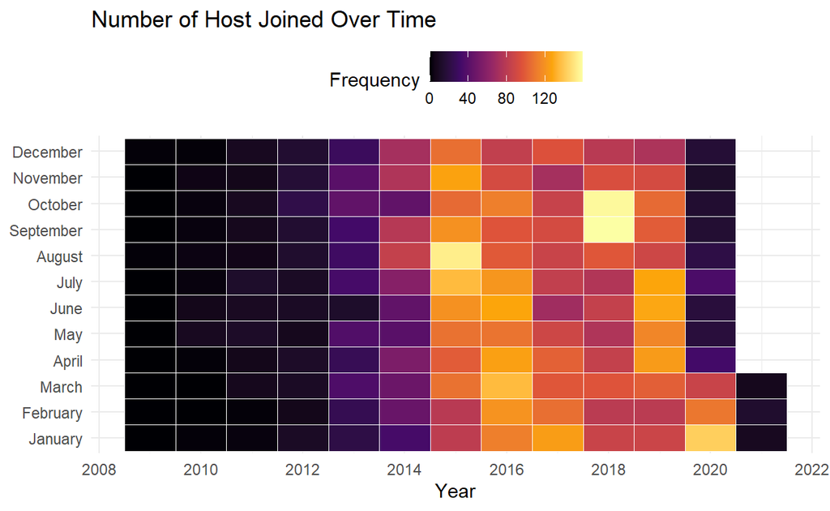

```r
df_viz %>%
  ggplot(aes(x = year,
             y = month,
             fill = frequency
             )
         ) +
  geom_tile(color = "white") +
  scale_x_continuous(breaks = seq(2000, 2025, 2) ) +
  theme_minimal() +
  theme(legend.position = "top") +
  scale_fill_viridis_c(option = "B") +
  labs(x = "Year",
       y = NULL,
       fill = "Frequency",
       title = "Number of Host Joined Over Time"
       )
```

Based on the heatmap, we can see that a large number of hosts started to join Airbnb from the year 2015, with the highest record of number of host joined in a single is on August 2015, September 2018, and October 2018. The number of new hosts are currently going down since April 2020, perhaps due to the global COVID-19 pandemic.

# Conclusion

We have done some data analysis to better understand the information regarding the room listing and host from Airbnb in Bangkok. We have saw what is the most common room type available, is there any correlation between room price and the review score, who are the top 10 host, etc. You can continue further by building a beautiful analytics dashboard in Tableau or using any libraries from python, such as plotly dash, flask, or streamlit.

Don’t forget to close your database connection if you are finished.

```r
#dbDisconnect(duck_con, shutdown = T)
    #duckdb::duckdb_shutdown(duckdb::duckdb())
```